# Demographie & Arbeitsmarkt

Qiang Qin, Shihan Hu, Yuechen Wang, Yuqin Huang

Dr.Scheipl, Daniel, Eugen

2025-11-29

## Agenda

1. Überblick und Terminologie
2. Datenanalyse

   Verlauf über die Runden  
   Zusammenhang  
   Antikörper
3. Zusammenfassung und Diskussion

## Überblick

**KoCo19**: Prospektive COVID-19 Kohorte München

- **Erhebungsart**: Längsschnittdaten
- 3000 Haushalte untersucht (Erwachsene und Kinder)

  – 350 Haushalte mit Kindern, darunter 436 Kinder

  – Zweistufige Klumpenstichprobe + Random-Route

  – Einschluss: Deutschkenntnisse

  – Ausschluss: Unerreichbarkeit
- 6 Runden von Messungen von April 2020 bis August 2022

## Terminologie

- **Seropositivität**: gewisse Konzentration von Antikörpern kann im Blut nachgewiesen werden (≈ COVID positiv getestet)
- **Seroprävalenz**: der kumulative Anteil der Personen, die jemals seropositiv getestet wurden
- **Anti-N**: Antikörper gebildet als Immunreaktion auf Infektion

## Agenda

1. Überblick und Terminologie

2. Datenanalyse

   Verlauf über die Runden  
   Zusammenhang  
   Antikörper

3. Zusammenfassung und Diskussion

## Seroprävalenz

- Imputation: $X_i \sim B(\hat{\pi}_i)$ mit $50$ Iterationen
  - gleiche Wahrscheinlichkeit für alle Teilnehmenden (iid.)
  - frühere Seroprävalenz möglich
  - Testzeitpunkte in einer Runde gleichverteilt

## Agenda

1. Überblick und Terminologie

2. Datenanalyse

   Verlauf über die Runden  
   Kinderbetreuung  
   Antikörper

3. Zusammenfassung und Diskussion

## Trend

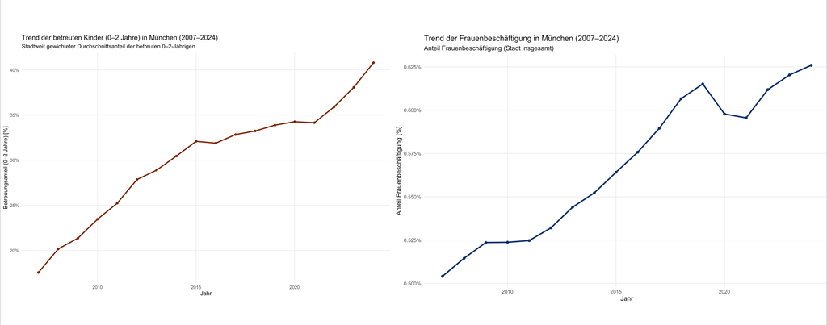

# Korr

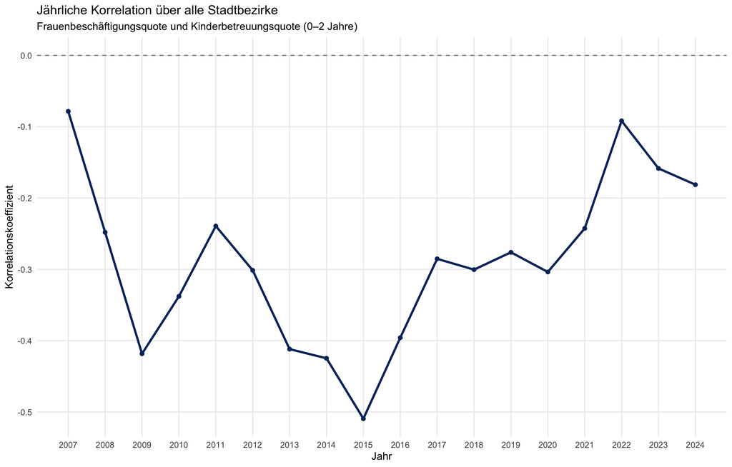

## Agenda

1. Überblick und Terminologie

2. Datenanalyse

   Verlauf über die Runden  
   Zusammenhang  
   Antikörper

3. Zusammenfassung und Diskussion

## Nachweisbarkeit der Antikörper

Wie lange es dauert, bis Antikörper im Blut verschwinden

- **Methode: NPMLE (Turnbull) + EM Algorithmus**

  $$\big(t(\text{last P})-t(\text{first P}), \ t(\text{first N}) - t(\text{first P})]$$
- **Unsicherheit:**
  - kleine Stichprobe ($n = 159$)
  - komplexe Zensierung
  - Annahme: Genaue Zeit der ersten Seropositivität bekannt

## Agenda

1. Überblick und Terminologie

2. Datenanalyse

3. Zusammenfassung und Diskussion

## **Diskussion**

- Hohe Dropout Rate —> 8,7% complete cases
- Ungleiche Zeitintervalle zwischen zwei Messungen
- Einfluss von Zeit und weitere Faktoren nicht mit Sicherheit zu quantifizieren
- Größere Datenmenge, längerer Studienverlauf tragen zur Sicherheit der Analyse bei

## Literatur

- [1] Glynn, J.R., Moss, P.A.H. Systematic analysis of infectious disease outcomes by age shows lowest severity in school-age children. Sci Data 7, 329 (2020).
- [2] Radon, K., Saathoff, E., Pritsch, M. et al. Protocol of a population-based prospective COVID-19 cohort study Munich, Germany (KoCo19). BMC Public Health 20, 1036 (2020).
- [3] Beyerl J, Rubio-Acero R, Castelletti N, Paunovic I, Kroidl I, Khan ZN, Bakuli A, Tautz A, Oft J, Hoelscher M, Wieser A; KoCo19 Study group (members listed in the supplementary material). A dried blood spot protocol for high throughput analysis of SARS-CoV-2 serology based on the Roche Elecsys anti-N assay. EBioMedicine. 2021 Aug;70:103502.
- [4] Le Gleut R, Plank M, Pütz P, Radon K, Bakuli A, Rubio-Acero R, Paunovic I, Rieß F, Winter S, Reinkemeyer C, Schälte Y, Olbrich L, Hannes M, Kroidl I, Noreña I, Janke C, Wieser A, Hoelscher M, Fuchs C, Castelletti N; KoCo19/ORCHESTRA-study group. The representative COVID-19 cohort Munich (KoCo19): from the beginning of the pandemic to the Delta virus variant. BMC Infect Dis. 2023 Jul 13;23(1):466.
- [5] Dunay GA, Barroso M, Woidy M, Danecka MK, Engels G, Hermann K, Neumann FS, Paul K, Beime J, Escherich G, Fehse K, Grinstein L, Haniel F, Haupt LJ, Hecher L, Kehl T, Kemen C, Kemper MJ, Kobbe R, Kohl A, Klokow T, Nörz D, Olfe J, Schlenker F, Schmiesing J, Schrum J, Sibbertsen F, Stock P, Tiede S, Vettorazzi E, Zazara DE, Zapf A, Lütgehetmann M, Oh J, Mir TS, Muntau AC, Gersting SW; C19.CHILD Study Group. Long-Term Antibody Response to SARS-CoV-2 in Children. J Clin Immunol. 2023 Jan;43(1):46-56.